# Time Varying Analysis

BH Analytics, LLC

# Objectives

- Review non-time to event data
- Understand motivating dataset
- Consider Follow-up time
- Fit Poisson models to account for follow-up time
- Cox proportional Hazards models
- Parametric Survival Models

# Time to Event Data

- Time to event data is defined as a dataset where we have noted the outcome for each unit (person in this case), as well as the time that the outcome occurred.
- We also typically denote the follow-up time for the patient to establish what length of time the patient is at risk for an event.
- This is in contrast to the way cross-sectional data is usually presented.
- An example of a **non-time** to event dataset presentation might be data on college admissions, like the data shown below.

```r
library(data.table)
# Import admissions data
dt_admit <- fread('Data/admit.csv')
dt_admit
```

```
##      admit gre  gpa rank
##   1:     0 380 3.61    3
##   2:     1 660 3.67    3
##   3:     1 800 4.00    1
##   4:     1 640 3.19    4
##   5:     0 520 2.93    4
##  ---
## 396:     0 620 4.00    2
## 397:     0 560 3.04    3
## 398:     0 460 2.63    2
## 399:     0 700 3.65    2
## 400:     0 600 3.89    3
```

# Non-Time to Event Data

- In this dataset, there is no indicator of when students applied to the program, or how long it took prior to being accepted or rejected. But that is OK for this use case!
- We can ask a number of reasonable questions using non-time to event data like this.
- What is the overall rate of admissions?
- Is GRE score associated with admission probability?
- Is class rank associated with admission probability?

```r
dt_admit[,list(admit_prob = mean(admit))]
```

```
##    admit_prob
## 1:     0.3175
```

```r
dt_admit[,list(admit_prob = mean(admit)),
         by=list(rank)][order(rank)]
```

```
##    rank admit_prob
## 1:    1  0.5409836
## 2:    2  0.3576159
## 3:    3  0.2314050
## 4:    4  0.1791045
```

```r
dt_admit[,list(admit_prob = mean(admit)),
         by=list(low_gpa=gpa<3.0)]
```

```
##    low_gpa admit_prob
## 1:   FALSE  0.3363363
## 2:    TRUE  0.2238806
```

```r
dt_admit[,list(admit_prob = mean(admit)),
         by=list(low_gre=gre<680)]
```

```
##    low_gre admit_prob
## 1:    TRUE  0.2890365
## 2:   FALSE  0.4040404
```

- We could even fit a multivariate model to account for all of these things at once:

```r
mod1 <-
  glm(admit~gre+gpa+factor(rank),
      data=dt_admit,
      family=binomial(link = "logit"))
summary(mod1)
```

```
##
## Call:
## glm(formula = admit ~ gre + gpa + factor(rank), family = binomial(link = "logit"),
##     data = dt_admit)
##
## Deviance Residuals:
##     Min       1Q   Median       3Q      Max
## -1.6268  -0.8662  -0.6388   1.1490   2.0790
##
## Coefficients:
##                Estimate Std. Error z value Pr(>|z|)
## (Intercept)   -3.989979   1.139951  -3.500 0.000465 ***
## gre            0.002264   0.001094   2.070 0.038465 *
## gpa            0.804038   0.331819   2.423 0.015388 *
## factor(rank)2 -0.675443   0.316490  -2.134 0.032829 *
## factor(rank)3 -1.340204   0.345306  -3.881 0.000104 ***
## factor(rank)4 -1.551464   0.417832  -3.713 0.000205 ***
## ---
## Signif. codes:  0 '***' 0.001 '**' 0.01 '*' 0.05 '.' 0.1 ' ' 1
##
## (Dispersion parameter for binomial family taken to be 1)
##
##     Null deviance: 499.98  on 399  degrees of freedom
## Residual deviance: 458.52  on 394  degrees of freedom
## AIC: 470.52
##
## Number of Fisher Scoring iterations: 4
```

# Non-Time to Event Shortcomings

- There are some shortcomings to this approach, however.
- What if there was a sort of rolling admissions process, where the top students might get admitted shortly after applying, but the middle of the road students take longer to get admitted.
- Can we answer that sort of question with this data? Why not?
- The reason we cannot is because of the denominator. In all the analyses above, the denominator was always simply per-person. We were estimating the probability of being accepted for each person (per-person), so we cannot make any assessment of how ‘quickly’ the event happens to each person. We can only make statements about the overall probability of the event eventually happening (and how that probability differs for low versus high GRE, etc)
- In this case (student applications and admissions), it may be fair to ignore the concept of follow-up time, or at risk time. If we are simply collecting applications, then evaluating them all at once at some future date, we don’t care how early someone applied.
- But what if we are following people through time, and looking at the probability of some event happening? Some examples may be:
  - Identifying instances of fraud among bank customers
  - Looking at risk factors for patients who develop cancer
- In both of these cases, I care about follow-up time. If a customer opens an account, and goes 1 month without a fraud event, that is different than a customer who opens an account and goes 5 years without a fraud event. Similarly, a patient who develops cancer 1 month following some exposure is different than a patient who develops cancer 5 years following the same exposure.
- If we use logistic regression for a problem, or more broadly…if we examine the risk of events per-person, we are assuming each person contributed equally. Another way of saying this, we are assuming equal follow-up time for each person in the cohort. That is reasonable in the analysis of admissions above. But it is often unreasonable in other contexts, especially when we have unequal follow-up times (or at-risk times).
- What is the answer to this challenge? Instead of modeling the risk of an event per-person, we will model the risk of an event per-person time!

# Motivating Time to Event Dataset

- I have simulated some data to help us consider different approaches to the analysis of time to event data, as well as how to deal with time-indexed and time-varying datasets.
- In this data, we are following people to see if they have an event. We start following them on a specific date (start_date), and we stop following them at a later date (end_date). If they have the event of interest, they are no longer at-risk, so we will stop following them once they have the event. However, they may never have the event, and then exit the risk set event-free. So there is a binary variable called ‘event’, which indicates if they had the event or not on the final date (stop_date).
- We have also collected other measurements on these people:
  - The measurements in the time_to_Event table were only measured at ‘baseline’ (the start date), like treatment, age, income, gender, and group.
  - We will look at some time-varying measurements later.

```r
## Import data
dt_surv <- fread('Data/time_to_event/time_to_event.csv')
dt_surv
```

```
##       person_id event gender treatment age    timev group income start_date  stop_date
##    1:         1     0   Male         1  32 71.14576     C    Low 2008-11-21 2009-10-22
##    2:         2     1   Male         0  38 55.32573     D    Low 2010-12-14 2011-01-27
##    3:         3     0   Male         0  39 48.32261     D    Low 2009-07-20 2009-08-10
##    4:         4     1 Female         0  36 90.16026     B Medium 2012-07-12 2013-02-16
##    5:         5     1 Female         0   0 52.45954     A    Low 2008-01-02 2008-01-31
##   ---
## 1996:      1996     0 Female         0  43 75.40909     A Medium 2008-03-24 2008-12-21
## 1997:      1997     0 Female         0  52 40.64898     A   High 2010-12-05 2012-11-24
## 1998:      1998     0 Female         0  49 74.80895     C    Low 2011-07-15 2013-07-04
## 1999:      1999     0 Female         1  50 84.38530     B Medium 2011-11-27 2012-11-12
## 2000:      2000     0   Male         0  42 41.63408     D   High 2012-11-28 2014-11-18
```

- As always, we should do the following:
  - Examine the data after import.
  - Clean the data as needed
- Take a moment to explore and understand the data:
  - Is patientID unique? How many people are in the dataset?
  - What is the earliest start and stop date?
  - Age should have a minimum value of 18. Fix it if needed!

```r
str(dt_surv)
```

```
## Classes 'data.table' and 'data.frame':   2000 obs. of  10 variables:
##  $ person_id : int  1 2 3 4 5 6 7 8 9 10 ...
##  $ event     : int  0 1 0 1 1 0 1 0 0 0 ...
##  $ gender    : chr  "Male" "Male" "Male" "Female" ...
##  $ treatment : int  1 0 0 0 0 0 0 0 0 0 ...
##  $ age       : int  32 38 39 36 0 13 34 30 31 27 ...
##  $ timev     : num  71.1 55.3 48.3 90.2 52.5 ...
##  $ group     : chr  "C" "D" "D" "B" ...
##  $ income    : chr  "Low" "Low" "Low" "Medium" ...
##  $ start_date: IDate, format: "2008-11-21" "2010-12-14" "2009-07-20" "2012-07-12" ...
##  $ stop_date : IDate, format: "2009-10-22" "2011-01-27" "2009-08-10" "2013-02-16" ...
##  - attr(*, ".internal.selfref")=<externalptr>
```

```r
dt_surv[,start_date_dt := as.Date(start_date)]
dt_surv[,stop_date_dt := as.Date(stop_date)]
library(Hmisc)
describe(dt_surv)
```

```
## dt_surv
##
##  12  Variables      2000  Observations
## --------------------------------------------------------------------------------------------------------------------------------------------------------
## person_id
##        n  missing distinct     Info     Mean      Gmd      .05      .10      .25      .50      .75      .90      .95
##     2000        0     2000        1     1000      667    101.0    200.9    500.8   1000.5   1500.2   1800.1   1900.0
##
## lowest :    1    2    3    4    5, highest: 1996 1997 1998 1999 2000
## --------------------------------------------------------------------------------------------------------------------------------------------------------
## event
##        n  missing distinct     Info      Sum     Mean      Gmd
##     2000        0        2    0.746      924    0.462   0.4974
##
## --------------------------------------------------------------------------------------------------------------------------------------------------------
## gender
##        n  missing distinct
##     2000        0        2
##
## Value      Female   Male
## Frequency    1177    823
## Proportion  0.588  0.412
## --------------------------------------------------------------------------------------------------------------------------------------------------------
## treatment
##        n  missing distinct     Info      Sum     Mean      Gmd
##     2000        0        2    0.457      375   0.1875   0.3048
##
## --------------------------------------------------------------------------------------------------------------------------------------------------------
## age
##        n  missing distinct     Info     Mean      Gmd      .05      .10      .25      .50      .75      .90      .95
##     2000        0       88        1    39.78    17.03       14       20       30       40       50       59       64
##
## lowest : -5 -4 -2 -1  0, highest: 82 83 86 89 92
## --------------------------------------------------------------------------------------------------------------------------------------------------------
## timev
##        n  missing distinct     Info     Mean      Gmd      .05      .10      .25      .50      .75      .90      .95
##     2000        0     2000        1    70.24    20.24    42.96    46.01    54.92    70.46    85.24    94.26    97.19
##
## lowest : 40.00296 40.02430 40.09203 40.11314 40.13638, highest: 99.93112 99.94008 99.94200 99.94661 99.95836
## --------------------------------------------------------------------------------------------------------------------------------------------------------
```

[output cut: 25 more lines]

```
##
## lowest : 2008-01-31 2008-02-04 2008-02-06 2008-02-09 2008-02-10, highest: 2014-11-27 2014-12-06 2014-12-07 2014-12-11 2014-12-12
## --------------------------------------------------------------------------------------------------------------------------------------------------------
## start_date_dt
##          n    missing   distinct       Info       Mean        Gmd        .05        .10        .25        .50        .75        .90        .95
##       2000          0       1210          1 2010-06-22      602.2 2008-03-28 2008-07-01 2009-03-25 2010-06-21 2011-09-04 2012-06-24 2012-09-30
##
## lowest : 2008-01-02 2008-01-03 2008-01-04 2008-01-05 2008-01-08, highest: 2012-12-27 2012-12-28 2012-12-30 2012-12-31 2013-01-01
## --------------------------------------------------------------------------------------------------------------------------------------------------------
## stop_date_dt
##          n    missing   distinct       Info       Mean        Gmd        .05        .10        .25        .50        .75        .90        .95
##       2000          0       1317          1 2011-06-15      664.3 2008-11-11 2009-04-08 2010-03-29 2011-06-23 2012-09-10 2013-07-04 2014-01-02
##
## lowest : 2008-01-31 2008-02-04 2008-02-06 2008-02-09 2008-02-10, highest: 2014-11-27 2014-12-06 2014-12-07 2014-12-11 2014-12-12
## --------------------------------------------------------------------------------------------------------------------------------------------------------
```

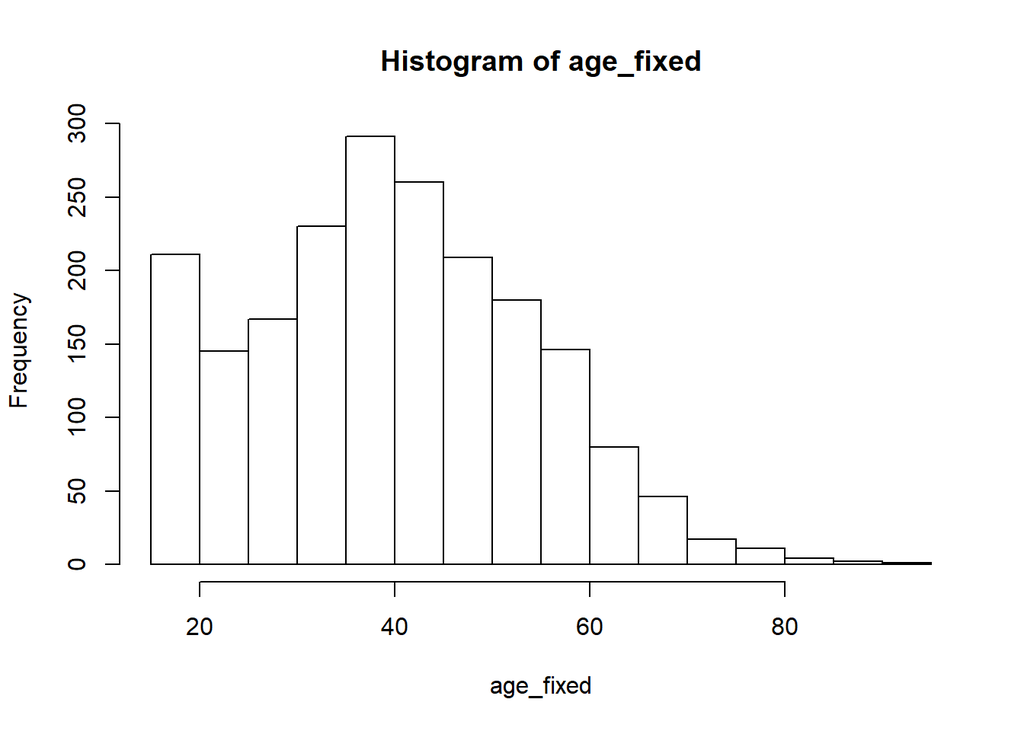

```
## $breaks
##  [1] 15 20 25 30 35 40 45 50 55 60 65 70 75 80 85 90 95
##
## $counts
##  [1] 211 145 167 230 291 260 209 180 146  80  46  17  11   4   2   1
##
## $density
##  [1] 0.0211 0.0145 0.0167 0.0230 0.0291 0.0260 0.0209 0.0180 0.0146 0.0080 0.0046 0.0017 0.0011 0.0004 0.0002 0.0001
##
## $mids
##  [1] 17.5 22.5 27.5 32.5 37.5 42.5 47.5 52.5 57.5 62.5 67.5 72.5 77.5 82.5 87.5 92.5
##
## $xname
## [1] "age_fixed"
##
## $equidist
## [1] TRUE
##
## attr(,"class")
## [1] "histogram"
```

```r
## Fix age!
dt_surv[,age_fixed := pmax(18,age)]
dt_surv[,hist(age_fixed)]
```

# Standard Approaches to Analyzing the Outcome

- If we were to ignore the time-to-event nature of this data, we might consider summarizing the probability of the event occurring without regard to follow-up time. We would find an overall event rate of 0.46, or 46%. How would you present this result in words?

```r
## Quantify event rate per person
dt_surv[,list(.N,event_rate=sum(event)/.N)]
```

```
##       N event_rate
## 1: 2000      0.462
```

- Out of 2000 people, the outcome occurred 46.2% of the time.
- We could investigate differences in the overall rate as a function of the other patient variables:

```r
## Quantify event rate per person
dt_surv[,list(.N,event_rate=sum(event)/.N),
        by=gender]
```

```
##    gender    N event_rate
## 1:   Male  823  0.4993925
## 2: Female 1177  0.4358539
```

- We would interpret this data to say the event occurs more often in males versus females. We could express this either by the absolute difference in risk, or by the relative difference in risk.

```r
male_rate <- 0.499
female_rate <- 0.436
## Absoulte difference
male_rate - female_rate
```

```
## [1] 0.063
```

```r
## Relative difference (relative risk)
male_rate/female_rate
```

```
## [1] 1.144495
```

- The absolute risk of the outcome among males is 6% higher than among females.
- The risk of the outcome among males is 1.14 times the risk of the outcome among females.
- But this ignores the key concept of follow-up time. How can we estimate the risk of the event using person-time as a denominator instead of person?

# Quantifying Person-Time

- In order to consider the impact of person time, we need to assess how long each person was ‘at-risk’ of having the event.
- In this dataset, we have identified the time interval each patient is at risk according to start_date and stop_date. This is a common way to express time to event data.
- We can ‘normalize’ this data by thinking of the start_date as day 0, then calculating how many days until the stop_date. We can simply subtract the date objects, then type cast the result to numeric (I prefer this to the datediff class that otherwise would be present).

```r
## Establish follow-up time numbers
dt_surv[,start_day:=0]
dt_surv[,stop_day:=as.numeric(stop_date_dt-start_date_dt)]
```

- Now that we have created this, we can use it to quantify the total amount of follow-up time.
- Try to answer these question, I will show you the code on the next slide:
  - What is the minimum follow-up time for these patients? What about the max?
  - What is the average follow-up time?
  - What is the total amount of follow-up time across all patients?
  - What is the average event rate per patient?
  - What is the average event rate per patient-year (instead of per-patient)?
  - What is the average event rate per patient-day?
  - What is the average event rate per patient-2 years?
  - Is the average event rate per patient-year different for Males versus Females?
  - Try and interpret both of these results as you would explain them to a non-statistician.

# Results from Prior Slide

- How did you do?
  - What is the minimum follow-up time for these patients? What about the max?
  - What is the average follow-up time?
  - What is the total amount of follow-up time across all patients?
  - What is the average event rate per patient?
  - What is the average event rate per patient-year (instead of per-patient)?
  - What is the average event rate per patient-day?
  - What is the average event rate per patient-2 years?
  - What is the average event rate per patient-10 years?
  - Is the average event rate per patient-year different for Males versus Females?
  - Try and interpret both of these results as you would explain them to a non-statistician.
  - Extra credit - what length of time corresponds to the average event rate per patient?

```r
## Min, max, median, average follow-up time (in days)
dt_surv[,describe(stop_day)]
```

```
## stop_day
##        n  missing distinct     Info     Mean      Gmd      .05      .10      .25      .50      .75      .90      .95
##     2000        0      586    0.988    358.6      292     21.0     41.9    118.0    305.5    646.2    720.0    720.0
##
## lowest :  21  22  23  24  25, highest: 714 715 717 719 720
```

```r
## Total follow-up time across all patients
dt_surv[,sum(stop_day)/365.25] #1,963 patient years of follow-up
```

```
## [1] 1963.485
```

```r
## Average event rate per patient
dt_surv[,list(v1=sum(event)/.N)] #.46 events per patient
```

```
##       v1
## 1: 0.462
```

```r
## Average event rate per patient-year (assume 365.25 days in a year)
dt_surv[,list(v1=365.25*sum(event)/sum(stop_day))] #.47 events per patient-year
```

```
##           v1
## 1: 0.4705918
```

```r
## Average event rate per patient-day
dt_surv[,list(v1=sum(event)/sum(stop_day))] #0.001 events per patient-day
```

```
##            v1
## 1: 0.00128841
```

```r
## Average event rate per patient-two years
dt_surv[,list(v1=2*365.25*sum(event)/sum(stop_day))] #.94 events per patient-2 years
```

```
##           v1
## 1: 0.9411835
```

```r
## Average event rate per patient - 10 years
dt_surv[,list(v1=10*365.25*sum(event)/sum(stop_day))] #4.7 events per patient-10 years
```

```
##          v1
## 1: 4.705918
```

```r
## Average event rate per patient-year, stratified by Gender
dt_surv[,list(v1=365.25*sum(event)/sum(stop_day)),
        by=gender]
```

```
##    gender        v1
## 1:   Male 0.5520293
## 2: Female 0.4208507
```

```r
## Length of time corresponding to per-patient calculation is simply the average follow-up time!
dt_surv[,list(v1=358.6*sum(event)/sum(stop_day))]
```

```
##           v1
## 1: 0.4620238
```

# Visualizing This Data

- Let’s look at the following diagram to think further about this dataset. Here are the first few rows of data, and what they might look like visually.
- This data is what we would call ‘right-censored’. That means some people will end follow-up without having the event.
- Follow-up time is also irregular in this dataset. As we have previously noted, there is a different amount of follow-up for each person.
- The math we implemented in the last slide can also be seen visually here. We are summing up the number of events (indicated by the shape at the end of the line), and dividing by the follow-up time (which is the total length of each line).

```r
## Sample Data
t1 <-
  dt_surv[1:10,
        list(person_id,event,start_day,stop_day)]
t1
```

```
##     person_id event start_day stop_day
##  1:         1     0         0      335
##  2:         2     1         0       44
##  3:         3     0         0       21
##  4:         4     1         0      219
##  5:         5     1         0       29
##  6:         6     0         0      131
##  7:         7     1         0      200
##  8:         8     0         0      302
##  9:         9     0         0      720
## 10:        10     0         0      720
```

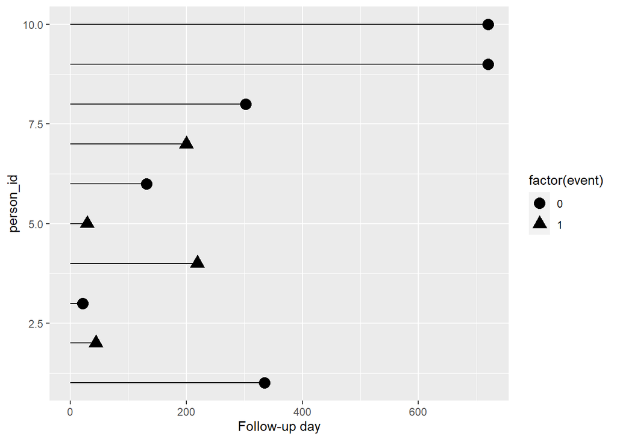

```r
## Quick ggplot code to make the vis!
library(ggplot2)
t2 <-
  melt(t1,
       id.vars = c('person_id','event'))
ggplot(t2,
       aes(y=person_id,x=value,group=person_id)) +
  geom_line() +
  geom_point(data=t2[variable == 'stop_day'],
             size=4,
             aes(x=value,shape=factor(event))) +
  xlab('Follow-up day')
```

# General Linear Models

- We can generalize the ordinary linear model to a more flexible framework
- In regular regression, the predictor variables are on the same scale as the outcome
- We assume a normal distribution

$$E(X) = B_{0} + B_{1}*X_{1} + B_{2}*X_{2} + ... + B_{k}*X_{k} + e$$

- A more general framework would be to allow some function to link the predictors to the outcome
- This is called the link function, and in normal regression it is identity
- We can also consider different distributional families for the outcome
- The combination of the link function and the distributional family is the general linear model

# Poisson Regression

$$ln(\lambda) = B_{0} + B_{1}*X_{1} + B_{2}*X_{2} + ... + B_{k}*X_{k}$$

- In Poisson regression, we are modeling a count outcome
- The distributional family we use is the Poisson distribution, where the mean is equal to the variance
- The only parameter is therefore lambda ($\lambda$)
- The link function is simply log
- Predictors are on the log scale here

# Extending Poisson Model to Account for Follow-up Time

- We can actually extend this Poisson model to directly account for different follow-up times.
- Consider the following:

$$\lambda = \mathsf{event}$$
$$t = \mathsf{follow-up time}$$

- We can then use a Poisson regression to directly model the outcome of number of events per unit time:

$$ln(\frac{\lambda}{t}) = B_{0} + B_{1}*X_{1} + B_{2}*X_{2} + ... + B_{k}*X_{k}$$

- And with some algebraic manipulation we get the following:

$$ln(\lambda) - ln(t) = B_{0} + B_{1}*X_{1} + B_{2}*X_{2} + ... + B_{k}*X_{k}$$

$$ln(\lambda) = B_{0} + B_{1}*X_{1} + B_{2}*X_{2} + ... + B_{k}*X_{k} + ln(t)$$

- So we can add the log of follow-up time as an ‘offset’ to the Poisson model.

# Poisson Example

- Here is some actual calculations and then the corresponding Poisson model, following what we did earlier.
- First, we can calculate the event rates per day and per year:

```r
## Average event rate per patient-day
dt_surv[,list(v1=sum(event)/sum(stop_day))] #0.001 events per patient-day
```

```
##            v1
## 1: 0.00128841
```

```r
## Average event rate per patient-year (365.25) days
dt_surv[,list(v1=365.25*sum(event)/sum(stop_day))] #0.47 events per patient-day
```

```
##           v1
## 1: 0.4705918
```

- Now, implement the same thing in a Poisson regression:
- The offset function in the formula constrains the value of the parameter associated with the offset to be 1, so we get this model:

$$ln(\lambda) = B_{0} + ln(t)$$

- Which is equal to this model:

$$ln(\frac{\lambda}{t}) = B_{0}$$

```r
mod2 <-
  glm(event ~ offset(log(stop_day)),
      family=poisson(link='log'),
      dt_surv)
summary(mod2)
```

```
##
## Call:
## glm(formula = event ~ offset(log(stop_day)), family = poisson(link = "log"),
##     data = dt_surv)
##
## Deviance Residuals:
##    Min      1Q  Median      3Q     Max
## -1.362  -1.240  -0.327   1.028   2.296
##
## Coefficients:
##             Estimate Std. Error z value Pr(>|z|)
## (Intercept)  -6.6543     0.0329  -202.3   <2e-16 ***
## ---
## Signif. codes:  0 '***' 0.001 '**' 0.01 '*' 0.05 '.' 0.1 ' ' 1
##
## (Dispersion parameter for poisson family taken to be 1)
##
##     Null deviance: 2883.4  on 1999  degrees of freedom
## Residual deviance: 2883.4  on 1999  degrees of freedom
## AIC: 4733.4
##
## Number of Fisher Scoring iterations: 6
```

- So if we exponentiate the estimate for beta, we should get the one day rate!

```r
exp(summary(mod2)$coefficients)
```

```
##               Estimate Std. Error      z value Pr(>|z|)
## (Intercept) 0.00128841   1.033444 1.421301e-88        1
```

- We can also use the predict function to get the rate, but we must specify the offset term (stop_day). We can also specify type = ‘response’ to get the prediction on the scale of the outcome, so we don’t need to exponentiate.

```r
# One day rate
predict(mod2,
        type = 'response',
        newdata=data.frame(stop_day=1))
```

```
##          1
## 0.00128841
```

```r
# 365.25 day rate
predict(mod2,
        type = 'response',
        newdata=data.frame(stop_day=365.25))
```

```
##         1
## 0.4705918
```

# Adding Predictors into the Model

- We now have a model to use for estimating the event rate. Let’s add a predictor into the model to see if treatment is associated with the outcome per unit time.
- We can first do this by simply counting up the outcomes and follow-up time like so:

```r
## Average event rate per patient-year (365.25) days
dt_surv[,list(v1=365.25*sum(event)/sum(stop_day)),
        by=treatment]
```

```
##    treatment        v1
## 1:         1 0.3506797
## 2:         0 0.5023009
```

- It certainly looks like treatment is associated with the outcome, since the 365 day event rate is 0.35 for those treated, but 0.5 for those not treated.
- We could express this difference as a relative risk difference as well:

```r
treat0 = 0.5023
treat1 = 0.3506
treat1/treat0
```

```
## [1] 0.6979892
```

- Among the treated, the treatment rate is 0.69 times the rate of the untreated.
- Now let’s fit the Poisson Model and get an estimate for treatment.

$$ln(\lambda) = B_{0} + B_{\mathsf{treatment}}*X_{\mathsf{treatment}} + ln(t)$$

```r
mod3 <-
  glm(event ~ treatment + offset(log(stop_day)),
      family=poisson(link='log'),
      dt_surv)
summary(mod3)$coefficients
```

```
##               Estimate Std. Error     z value     Pr(>|z|)
## (Intercept) -6.5891381 0.03580554 -184.025665 0.000000e+00
## treatment   -0.3593259 0.09069939   -3.961723 7.441083e-05
```

```r
exp(summary(mod3)$coefficients[,'Estimate'])
```

```
## (Intercept)   treatment
## 0.001375225 0.698146816
```

- And we get the same relative risk estimate of 0.69. Do you see the connection?
- Now what if we wanted to estimate the actual risk for treated versus not treated? We can create a new dataframe, then make predictions for it.

```r
df1 <- data.frame(treatment=c(0,1),
                  stop_day=365.25)
df1$predicted_rate <- predict(mod3,df1,type = 'response')
df1
```

```
##   treatment stop_day predicted_rate
## 1         0   365.25      0.5023009
## 2         1   365.25      0.3506797
```

# Multiple Predictors

- Now the real power of using a general linear model is the ability to simultaneously model multiple predictors, like so:

```r
mod4 <-
  glm(event ~ treatment + gender + income + group + offset(log(stop_day)),
      family=poisson(link='log'),
      dt_surv)
summary(mod4)$coefficients
```

```
##                Estimate Std. Error    z value     Pr(>|z|)
## (Intercept)  -6.2715175 0.09687243 -64.739966 0.000000e+00
## treatment    -0.3655857 0.09083772  -4.024602 5.707181e-05
## genderMale    0.2871803 0.06638928   4.325703 1.520465e-05
## incomeLow    -0.2028189 0.09036724  -2.244385 2.480762e-02
## incomeMedium -0.1305617 0.09503452  -1.373834 1.694931e-01
## groupB       -0.2521538 0.08876961  -2.840542 4.503697e-03
## groupC       -0.2902662 0.08950509  -3.243014 1.182725e-03
## groupD       -0.6560981 0.09568883  -6.856580 7.052858e-12
```

```r
exp(summary(mod4)$coefficients[,'Estimate'])
```

```
##  (Intercept)    treatment   genderMale    incomeLow incomeMedium       groupB       groupC       groupD
##  0.001889359  0.693790204  1.332664413  0.816426073  0.877602360  0.777125227  0.748064374  0.518871953
```

- Can you interpret each of these estimates? It should be done the same way as before.
- For example, this model tell us that males have 1.33 times the risk of the event, compared with females.

# The Mean Variance Relationship in the Poisson Model

- It turns out the Poisson distribution is very strict. There is an assumption under the Poisson distribution that the mean equals the variance. This is rarely true in practice. As you saw on the prior slide, we still get unbiased estimated for the risk rates. But what is incorrect is the estimate of the variance (or the standard error).
- We can fit another related model call the ‘quasipoisson’ to fix this. Essentially, we are relaxing the assumption that the mean equals the variance by adding an additional parameter into the model. We will not go heavily into the theoretical details of this approach, but here is how to fit the model:

```r
mod5 <-
  glm(event ~ treatment + gender + income + group + offset(log(stop_day)),
      family=quasipoisson(link='log'),
      dt_surv)
summary(mod5)$coefficients
```

```
##                Estimate Std. Error     t value      Pr(>|t|)
## (Intercept)  -6.2715175  0.1741330 -36.0156819 3.415895e-219
## treatment    -0.3655857  0.1632853  -2.2389381  2.526996e-02
## genderMale    0.2871803  0.1193380   2.4064444  1.619919e-02
## incomeLow    -0.2028189  0.1624396  -1.2485806  2.119652e-01
## incomeMedium -0.1305617  0.1708292  -0.7642818  4.447898e-01
## groupB       -0.2521538  0.1595677  -1.5802302  1.142129e-01
## groupC       -0.2902662  0.1608898  -1.8041306  7.136184e-02
## groupD       -0.6560981  0.1720054  -3.8144043  1.406690e-04
```

```r
exp(summary(mod5)$coefficients[,'Estimate'])
```

```
##  (Intercept)    treatment   genderMale    incomeLow incomeMedium       groupB       groupC       groupD
##  0.001889359  0.693790204  1.332664413  0.816426073  0.877602360  0.777125227  0.748064374  0.518871953
```

- And the interpretation of the results remains the same. Notice that the p-values are quite a bit higher in this model, which is the correct result.

# Survival Curves

- Another approach to analyzing data with follow-up time is a class of models generally called ‘time to event’. We will start this idea out with calculating survival curves.
- We often visualize time to event data in terms of survival curves, sometimes called Kaplan-Meier curves.
- The idea is we can plot the proportion of people who are at risk for the event over time. You may have seen them before, here is an example:

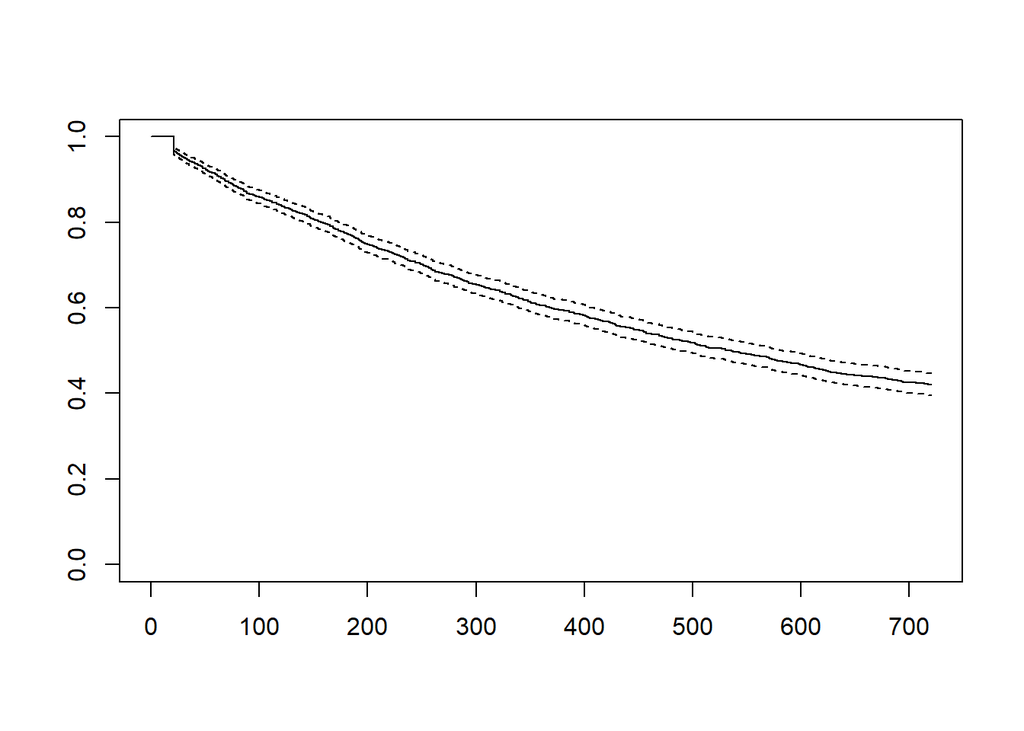

```r
## First create a survival object
surv1 <- survfit(Surv(stop_day,event) ~ 1,
             data=dt_surv)
## Next we can plot the object
plot(surv1)
```

- Recall that no one had the event for the first 21 days, and we can see that in this graph. After that, there is a steady decline in the population still at risk.

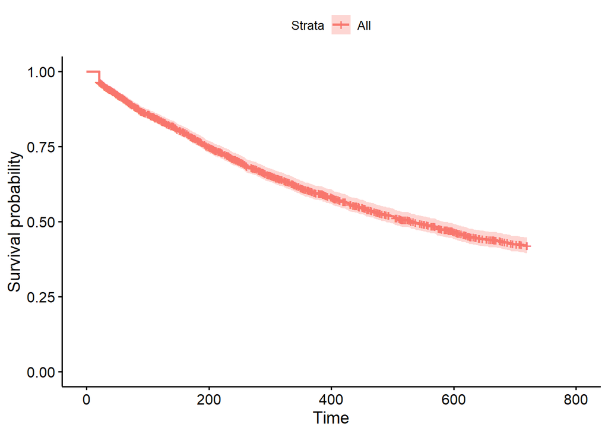

```r
library(survminer)
# Drawing curves with survminer instead!
ggsurvplot(surv1)
```

# Comparing Survival Curves

- We may also be interested in comparing survival between two different groups. For example, we could compare the survival curves between the treated and untreated individuals in our data set.
- We can do this visually using the following base plotting code:

[figure not shown]

```r
## First create a survival object
surv2 <- survfit(Surv(stop_day,event) ~ treatment,
             data=dt_surv)
## Next we can plot the object
plot(surv2,
     lty=2:3,
     col=c("red","blue"))
legend(0.5, 0.6, c("Treated", "Untreated"),
       lty=2:3,col=c("red","blue"))
title("Survival Curves by Treatment")
```

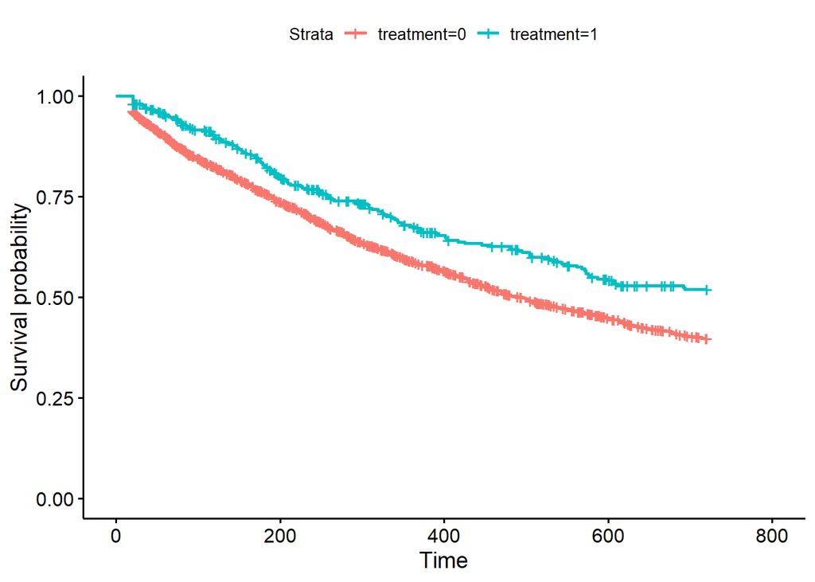

```r
# use survminer instead of base graphics
# Drawing curves with survminer instead!
ggsurvplot(surv2)
```

- We can also compare these two survival curves statistically using something called a log-rank test. You can think of this like a t-test, but for survival data. We will not go deep into the statistical theory here, but this test compares the hazard of the event (more on this later). We interpret the p-value like always, with the null hypothesis being that the hazards are not different.

```r
## Perform log rank test to get p-value
survdiff(Surv(stop_day,event) ~ treatment,
             data=dt_surv)
```

```
## Call:
## survdiff(formula = Surv(stop_day, event) ~ treatment, data = dt_surv)
##
##                N Observed Expected (O-E)^2/E (O-E)^2/V
## treatment=0 1625      780      733      3.06      14.8
## treatment=1  375      144      191     11.71      14.8
##
##  Chisq= 14.8  on 1 degrees of freedom, p= 1e-04
```

# Understanding ‘the Hazard’

- A key concept in time to event analysis is ‘the hazard’ of an event happening.
- The hazard is formally defined as the ‘risk of outcome per unit time’. So we have actually been calculating the hazard already!
- However, in all of our previous models, we have been calculating the average hazard over time. We have been assuming the hazard is constant, when the reality is the hazard may not be constant at all.
- Consider the hazard of engine failure in a car. Engines are not likely to fail when they are new, but as they get increasingly more mileage on them, the failure rate increases. Thus the hazard of engine failure is not constant over time!
- Consider the hazard of death for humans. We are more likely to die when we are very young or very old, but less likely to die in-between (especially in developing countries). This would be a ‘bathtub shaped hazard’, certainly not constant over time!
- Here is a graph from Wikipedia bathtub curve page demonstrating these different hazards:

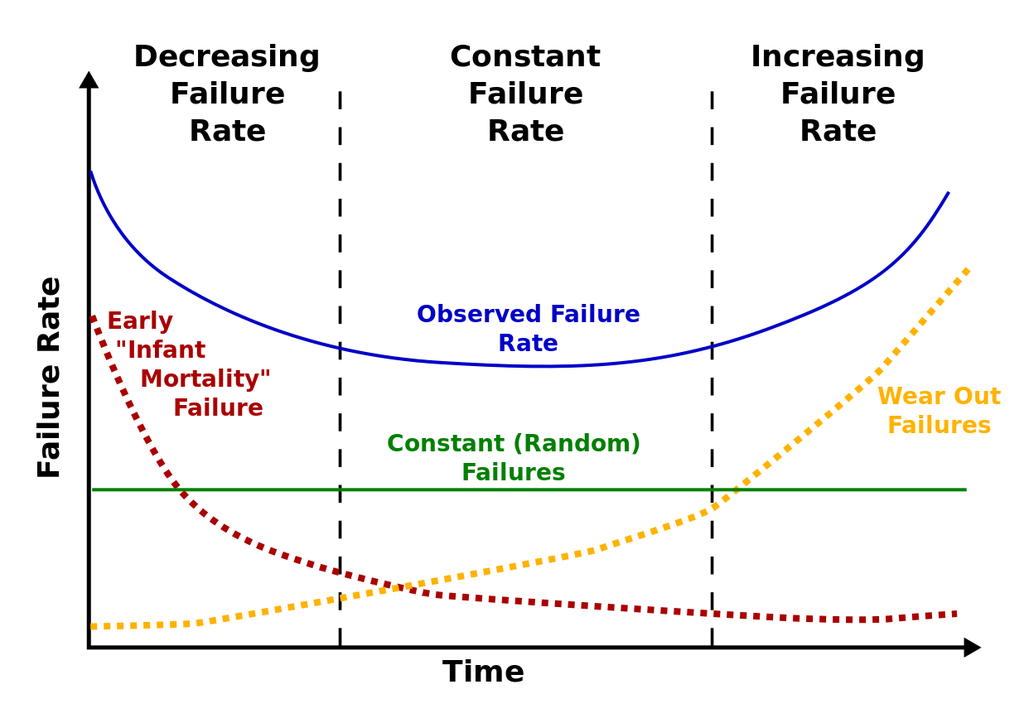

Bathtub Hazard

# Cox Proportional Hazards Models

- If we want to model the hazard directly, we can do so using a few different frameworks. The first one we will discuss is the Cox proportional hazards model.
- This is a clever model, where we actually just model the difference in the hazards across different covariates. We don’t ever actually need to specify the shape of the hazard (or model it parametrically). Instead, we compare the hazard of the events across different covariate values.
- As a result of this, the ‘baseline hazard shape’ is cancelled out (since it is in both the numerator and the denominator), and all we estimate is the ratio of the hazards. The actual model looks like this:

$$h_i(t)=h_0(t)exp(\beta_{1}x_{i1} + \beta_{2}x_{ik} + ... + \beta_{2}x_{ik})$$

Where

$$h_0(t) = \mathsf{baseline hazard}$$

- Here is the code to fit a model, we use the coxph function

```r
cox_mod1 <- coxph(Surv(stop_day,event) ~ treatment,
             data=dt_surv)
summary(cox_mod1)
```

```
## Call:
## coxph(formula = Surv(stop_day, event) ~ treatment, data = dt_surv)
##
##   n= 2000, number of events= 924
##
##               coef exp(coef) se(coef)      z Pr(>|z|)
## treatment -0.34798   0.70611  0.09074 -3.835 0.000126 ***
## ---
## Signif. codes:  0 '***' 0.001 '**' 0.01 '*' 0.05 '.' 0.1 ' ' 1
##
##           exp(coef) exp(-coef) lower .95 upper .95
## treatment    0.7061      1.416    0.5911    0.8435
##
## Concordance= 0.527  (se = 0.006 )
## Likelihood ratio test= 15.91  on 1 df,   p=7e-05
## Wald test            = 14.71  on 1 df,   p=1e-04
## Score (logrank) test = 14.86  on 1 df,   p=1e-04
```

- If we exponentiate the coefficients corresponding to treatment, we would get the following interpretation: “Among those with treatment = 1, the hazard of the outcome is 0.706 times the hazard compared to those with treatment = 0”

# Cox Model with Multiple Parameters

- We can extend this model to using multiple parameters similarly to the way we have done before, simply by adding more predictors into the equation.

```r
cox_mod1 <- coxph(Surv(stop_day,event) ~ treatment + gender + age + group + income,
             data=dt_surv)
summary(cox_mod1)
```

```
## Call:
## coxph(formula = Surv(stop_day, event) ~ treatment + gender +
##     age + group + income, data = dt_surv)
##
##   n= 2000, number of events= 924
##
##                   coef exp(coef)  se(coef)       z Pr(>|z|)
## treatment    -0.412316  0.662115  0.090972  -4.532 5.83e-06 ***
## genderMale    0.260903  1.298102  0.066507   3.923 8.75e-05 ***
## age          -0.043324  0.957601  0.002343 -18.489  < 2e-16 ***
## groupB       -0.265094  0.767134  0.088717  -2.988 0.002807 **
## groupC       -0.296936  0.743092  0.089537  -3.316 0.000912 ***
## groupD       -0.695349  0.498901  0.096079  -7.237 4.58e-13 ***
## incomeLow    -0.109711  0.896093  0.090763  -1.209 0.226754
## incomeMedium -0.049633  0.951578  0.095403  -0.520 0.602893
## ---
## Signif. codes:  0 '***' 0.001 '**' 0.01 '*' 0.05 '.' 0.1 ' ' 1
##
##              exp(coef) exp(-coef) lower .95 upper .95
## treatment       0.6621     1.5103    0.5540    0.7914
## genderMale      1.2981     0.7704    1.1395    1.4788
## age             0.9576     1.0443    0.9532    0.9620
## groupB          0.7671     1.3036    0.6447    0.9128
## groupC          0.7431     1.3457    0.6235    0.8856
## groupD          0.4989     2.0044    0.4133    0.6023
## incomeLow       0.8961     1.1160    0.7501    1.0706
## incomeMedium    0.9516     1.0509    0.7893    1.1472
##
## Concordance= 0.693  (se = 0.009 )
## Likelihood ratio test= 428.7  on 8 df,   p=<2e-16
## Wald test            = 417.1  on 8 df,   p=<2e-16
## Score (logrank) test = 424.6  on 8 df,   p=<2e-16
```

- We would correctly find that income is not associated with the outcome here, but the other variables are. We can summarize the effect measures just as we did before. That estimate is called the hazard ratio.
- As often in life, the strength is also the weakness. Since we did not estimate the baseline hazard, we did not have to worry about getting the estimated ‘shape’ correct. In that sense, this is a flexible model. No matter what the underlying hazard shape, we can estimate the ratio.
- However, since we did not estimate the underlying hazard, we cannot say anything about the actual times to failure! We can only comment an the *relative* times to failure.
- If you are interested in estimating the actual time to failure (and therefore being able to predict the time to failure!), we must parametrically model the baseline hazard.

# Parametric Hazard Models

- If we can assume a mathematical shape for the underlying hazard we can get more (statistical) power out of the model.
- But of course, if we get the shape of the hazard wrong, the model is wrong…
- There are a few different distributions commonly used to model the hazard, with varying degrees of flexibility:
  - exponential
  - weibull
- We use the survreg function to implement these models:

```r
# Exponential Distribution
par_model <- survreg(Surv(stop_day,event) ~ treatment + gender + age + group,
                     data=dt_surv,
                     dist="exponential")
summary(par_model)
```

```
##
## Call:
## survreg(formula = Surv(stop_day, event) ~ treatment + gender +
##     age + group, data = dt_surv, dist = "exponential")
##                Value Std. Error     z       p
## (Intercept)  4.70282    0.10480 44.87 < 2e-16
## treatment    0.41725    0.09078  4.60 4.3e-06
## genderMale  -0.26495    0.06639 -3.99 6.6e-05
## age          0.04355    0.00229 19.02 < 2e-16
## groupB       0.26131    0.08867  2.95 0.00321
## groupC       0.29737    0.08948  3.32 0.00089
## groupD       0.69031    0.09570  7.21 5.5e-13
##
## Scale fixed at 1
##
## Exponential distribution
## Loglik(model)= -6850.2   Loglik(intercept only)= -7072.6
##  Chisq= 444.89 on 6 degrees of freedom, p= 6.2e-93
## Number of Newton-Raphson Iterations: 5
## n= 2000
```

# Parametric Models

- The Weibull distribution is a more flexible extension of the exponential. In fact, the exponential is a subset of the Weibull distribution.
- If you find a substantially different answer between these two model fits, that implies the extra flexibility of the Weibull was needed, and the exponential distribution was in correct.

```r
# Weibull Distribution
par_model_2 <- survreg(Surv(stop_day,event) ~ treatment + gender + age + group,
                     data=dt_surv,
                     dist="weibull")
summary(par_model_2)
```

```
##
## Call:
## survreg(formula = Surv(stop_day, event) ~ treatment + gender +
##     age + group, data = dt_surv, dist = "weibull")
##                Value Std. Error     z       p
## (Intercept)  4.73855    0.10188 46.51 < 2e-16
## treatment    0.40525    0.08664  4.68 2.9e-06
## genderMale  -0.25627    0.06336 -4.04 5.2e-05
## age          0.04219    0.00231 18.28 < 2e-16
## groupB       0.25233    0.08453  2.99 0.00283
## groupC       0.28689    0.08535  3.36 0.00078
## groupD       0.66788    0.09189  7.27 3.6e-13
## Log(scale)  -0.04957    0.02745 -1.81 0.07101
##
## Scale= 0.952
##
## Weibull distribution
## Loglik(model)= -6848.6   Loglik(intercept only)= -7070.8
##  Chisq= 444.42 on 6 degrees of freedom, p= 7.8e-93
## Number of Newton-Raphson Iterations: 6
## n= 2000
```

```r
# Compare the models
anova(par_model,par_model_2)
```

```
##                              Terms Resid. Df    -2*LL Test Df Deviance   Pr(>Chi)
## 1 treatment + gender + age + group      1993 13700.34      NA       NA         NA
## 2 treatment + gender + age + group      1992 13697.15    =  1 3.191091 0.07404059
```

# Parametric Models Prediction

- Parametric models allow us to predict and exact mean to failure time since we have the hazard function modeled
- This may be unrealistic if outside the boundaries of our data!

```r
# Predict the mean time to failure for given covariates
# from model 2
predict(par_model_2,
        data.frame(gender='Male', treatment=0, age=50, group='B'),
        se.fit=T)
```

```
## $fit
##        1
## 938.1739
##
## $se.fit
##        1
## 75.92324
```